# Trabajo Camacol

Kevin Ramirez

1/4/2022

## Transformación de los datos

Cargamos la base a R y observamos como se componen los datos. La base contiene 1120 filas con 13 columnas las cuales son todas de tipo character. Además notamos que *Área* contiene no solo el tamaño del inmueble, también contiene la cantidad de habitaciones, baños y parqueaderos que contiene el inmueble por lo cual debemos transformarla en 4 columnas nuevas.

```r
base2 <-  read.xlsx2('ws_fr_vn_ver2_cs.xlsx', sheetIndex = 1)

summary(base2)
```

```
##     Ciudad              Zona           Constructora        Destacado
##  Length:1120        Length:1120        Length:1120        Length:1120
##  Class :character   Class :character   Class :character   Class :character
##  Mode  :character   Mode  :character   Mode  :character   Mode  :character
##    Proyecto            Precio              Área               Link
##  Length:1120        Length:1120        Length:1120        Length:1120
##  Class :character   Class :character   Class :character   Class :character
##  Mode  :character   Mode  :character   Mode  :character   Mode  :character
##    Consulta          Descipción          Estrato           Dirección
##  Length:1120        Length:1120        Length:1120        Length:1120
##  Class :character   Class :character   Class :character   Class :character
##  Mode  :character   Mode  :character   Mode  :character   Mode  :character
##  Publicación
##  Length:1120
##  Class :character
##  Mode  :character
```

### Eliminación de columnas

Eliminamos Zona y Direccion ya que la ubicación del inmueble está controlada por el estrato y la ciudad. De igual manera borramos el resto de las columnas que no brindan información relevante a la predicción del modelo.

```r
col_para_eliminar <- c("Zona", "Constructora", "Proyecto", "Consulta", "Dirección", "Publicación", "Descipción")

base <- base2[, !(names(base2) %in% col_para_eliminar)]
```

### Creación de nuevas columnas

Con la función separate() de dplyr y usando regex separamos las cuatro columnas y eliminamos los caracteres no numéricos para poder convertirlas a tipo numeric.

Las nuevas columnas son *Area_m2*’, *Habitaciones*, *Banios*, *Parqueadero* y *Es_destacado* la cual es una variable dummy que especifica si dicho proyecto esta destacado en fincaraiz o no.

```r
# Convertimos area en 4 columnas diferentes

base$Área <- gsub('Áreas desde ', "", base$Área)

base <- base %>%  separate(col = Área, c('Area_m2', 'Habitaciones', 'Banios', 'Parqueadero'), sep = " • ")

base$Area_m2 <- gsub(',','.', base$Area_m2)
base$Area_m2 <- as.numeric(gsub('m.*','', base$Area_m2))


#convertir a numeric
convertir_numeric <- c('Habitaciones', 'Banios', 'Parqueadero')
base[convertir_numeric] <- lapply(base[convertir_numeric], function (x) as.numeric(gsub('\\D+', '', x)))


#Eliminamos simbolos innecesarios

eliminar_simbolo <- c('Precio', 'Estrato')
base[eliminar_simbolo] <- lapply(base[eliminar_simbolo], function (x) gsub('$', '', x, fixed = T))
base[eliminar_simbolo] <- lapply(base[eliminar_simbolo], function (x) as.numeric(gsub('.', '', x, fixed = T)))

base['Es_destacado'] <- lapply(base['Destacado'], function (x) ifelse(x == 'Proyecto',0,1))
```

### Visualizamos los NAs

Con summary() nos damos una idea de la manera en que están distribuidos los datos. Curiosamente en estrato hay cifras que se encuentran en los millones, probablemente porque el webscrapper tomo el precio del inmueble como el estrato.

Observamos que hay una gran cantidad de NAs en habitaciones, parqueaderos y baños ya que estos datos no se encontraban en las publicaciones.

Adicionalmente, existen publicaciones que contienen un alto número de parqueaderos por inmueble. Investigando unas cuantas publicaciones es evidente que el scrapper tomo los datos de los parqueaderos de todo el conjunto por lo cual el dato es erróneo y debe ser corregido.

```r
summary(base)
```

```
##     Ciudad           Destacado             Precio              Area_m2
##  Length:1120        Length:1120        Min.   :  77900000   Min.   :  2.53
##  Class :character   Class :character   1st Qu.: 249166119   1st Qu.: 54.00
##  Mode  :character   Mode  :character   Median : 396956145   Median : 73.00
##                                        Mean   : 472428516   Mean   : 79.05
##                                        3rd Qu.: 534876500   3rd Qu.: 93.03
##                                        Max.   :4055205550   Max.   :469.00
##
##   Habitaciones       Banios       Parqueadero         Link
##  Min.   :1.000   Min.   :1.000   Min.   : 1.000   Length:1120
##  1st Qu.:2.000   1st Qu.:2.000   1st Qu.: 1.000   Class :character
##  Median :3.000   Median :2.000   Median : 1.000   Mode  :character
##  Mean   :2.471   Mean   :2.178   Mean   : 2.271
##  3rd Qu.:3.000   3rd Qu.:2.000   3rd Qu.: 1.000
##  Max.   :5.000   Max.   :7.000   Max.   :10.000
##  NA's   :136     NA's   :142     NA's   :625
##     Estrato           Es_destacado
##  Min.   :        2   Min.   :0.0000
##  1st Qu.:        3   1st Qu.:0.0000
##  Median :        4   Median :0.0000
##  Mean   : 15295144   Mean   :0.1071
##  3rd Qu.:        5   3rd Qu.:0.0000
##  Max.   :808400000   Max.   :1.0000
##
```

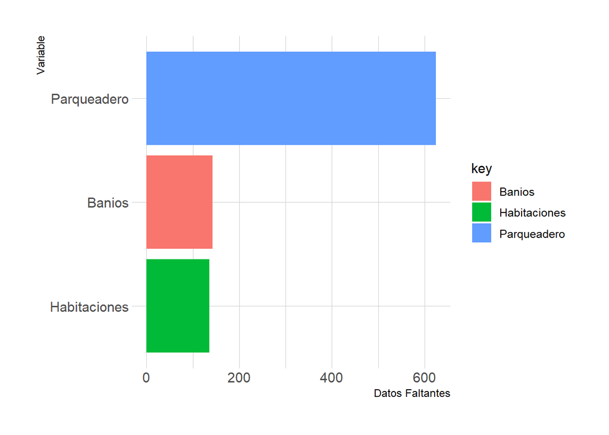

```r
base %>%
  gather(key = "key", value = "val") %>%
  mutate(is.missing = is.na(val)) %>%
  group_by(key, is.missing) %>%
  summarise(num_missing = n())%>%
  filter(is.missing == TRUE, num_missing > 1) %>%
  select(-is.missing) %>%
  arrange(desc(num_missing)) %>%
  ggplot(aes(x = reorder(key, num_missing), y = num_missing, fill = key)) +
  geom_col() +
  coord_flip() +
  xlab("Variable") +
  ylab("Datos Faltantes")+
  theme(legend.position='none') + theme_ipsum()
```

### Webscrapping

Para evitar que el for loop se detenga cuando no pueda conectarse al link lo metemos dentro de un try statement.

```r
for (i in 1:nrow(base)) {

  if (base[i,'Estrato'] > 6) {

    try({

    url <-  base[i, 'Link']
    pag <-  read_html(url) %>% html_nodes('p')
    base[i, 'Estrato'] <-  as.numeric(html_text(pag[12]))

    }
    )
  }
}
```

```
## Error in open.connection(x, "rb") : HTTP error 404.
## Error in open.connection(x, "rb") : HTTP error 404.
## Error in open.connection(x, "rb") : HTTP error 404.
## Error in open.connection(x, "rb") : HTTP error 404.
```

Hubo 4 links caídos dado que la publicación ya fue eliminada. Al filtrar la información se observa que esas publicaciones están ubicadas en Girón por lo que reemplazamos ese dato con la moda del estrato en Girón el cual es 3.

```r
base['Estrato'][base['Estrato']>7] <- 3
```

Usamos la moda para reemplazar los datos faltantes. De igual manera usamos la moda para reemplazar el número de parqueaderos cuya cifra es muy alta. De esta manera ya tenemos lo necesario para poder realizar le análisis exploratorio de los datos.

```r
mediana_hab <- as.numeric(names(sort(-table(base$Habitaciones)))[1])
mediana_par <- as.numeric(names(sort(-table(base$Parqueadero)))[1])
mediana_ba <- as.numeric(names(sort(-table(base$Banios)))[1])

base$Habitaciones  <-replace_na(base$Habitaciones, mediana_hab)
base$Banios <- replace_na(base$Banios, mediana_ba)
base$Parqueadero <- replace_na(base$Banios, mediana_par)

base$Parqueadero <- replace(base$Parqueadero, base$Parqueadero >5, mediana_par)

summary(base)
```

```
##     Ciudad           Destacado             Precio              Area_m2
##  Length:1120        Length:1120        Min.   :  77900000   Min.   :  2.53
##  Class :character   Class :character   1st Qu.: 249166119   1st Qu.: 54.00
##  Mode  :character   Mode  :character   Median : 396956145   Median : 73.00
##                                        Mean   : 472428516   Mean   : 79.05
##                                        3rd Qu.: 534876500   3rd Qu.: 93.03
##                                        Max.   :4055205550   Max.   :469.00
##   Habitaciones       Banios       Parqueadero        Link
##  Min.   :1.000   Min.   :1.000   Min.   :1.000   Length:1120
##  1st Qu.:2.000   1st Qu.:2.000   1st Qu.:2.000   Class :character
##  Median :3.000   Median :2.000   Median :2.000   Mode  :character
##  Mean   :2.535   Mean   :2.155   Mean   :2.141
##  3rd Qu.:3.000   3rd Qu.:2.000   3rd Qu.:2.000
##  Max.   :5.000   Max.   :7.000   Max.   :5.000
##     Estrato       Es_destacado
##  Min.   :2.000   Min.   :0.0000
##  1st Qu.:3.000   1st Qu.:0.0000
##  Median :4.000   Median :0.0000
##  Mean   :4.184   Mean   :0.1071
##  3rd Qu.:5.000   3rd Qu.:0.0000
##  Max.   :6.000   Max.   :1.0000
```

## Visualización de los Datos

Usando las APIs de geonames y leaflet podemos generar un mapa que nos muestre la distribución de los datos:

```r
#Reemplazamos nombres para que coincidan con los resultados de geonames

base[base==' Cali'] <- ' Santiago de Cali'
base[base==' El Retiro'] <- ' Retiro'

# Lista de las ciudades
ciudades <- unlist(list(unique(base$Ciudad)))

# Funcion para generar el query
GNsearchAF <- function(city) {
  res <- GNsearch(name=city, country="CO")
  return(res[1,c("name","adminName1","population","lng","lat")])
}

# Aplicamos el resultado de cada query a una nueva df
GNresult <- do.call(rbind, lapply(ciudades, GNsearchAF))
colnames(GNresult) <- c("Ciudad", "Departamento", "Población", "Longitud", "Latitud")
GNresult[,3:5] <- sapply(GNresult[,3:5], as.numeric)

Colombia <- GNcountryInfo('CO')

Colombia_children <- GNchildren(Colombia$geonameId)


conteo <- as.data.frame(table(base$Ciudad))

colnames(conteo) <- c('Ciudad', 'Freq')

GNresult <-cbind(GNresult[order(GNresult$Ciudad),], conteo[order(conteo$Ciudad),])
```

### Generamos el mapa dinamico usando el API de leaflet

El mapa nos muestra en que parte del territorio colombiano se encuentran las publicaciones, además nos indica la cantidad de publicaciones de acuerdo a la intensidad del color y el tamaño de cada circulo.

```r
GNresult$label <- with(GNresult, paste(
   Ciudad, "-,",
    Departamento, "-",
  "Cantidad Publicaciones:", Freq
  ))

leaflet(GNresult) %>% addProviderTiles(providers$CartoDB.Positron) %>%
  addCircles(lng = ~Longitud, lat = ~Latitud, weight = 15,
             radius = ~Freq*20, label = ~label)
```

[interactive chart not shown]

Graficamos la relación entre el precio el área y el estrato. Como es de esperarse, se puede observar un clustering en el precio de los inmuebles de acuerdo con su estrato.

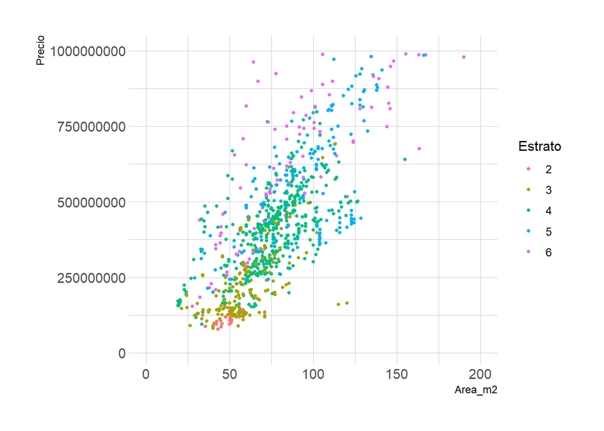

```r
base$Estrato <- factor(base$Estrato)
ggplot(base, aes(x=Area_m2, y= Precio, color=Estrato)) +
    geom_point(size=1) + theme_ipsum() + scale_y_continuous(limits = c(10000000, 1000000000)) + scale_x_continuous(limits = c(0,200))
```

Al graficar las frecuencias de baños y habitaciones notamos que la gran mayoría de publicaciones cuenta con 2 baños y 3 alcobas.

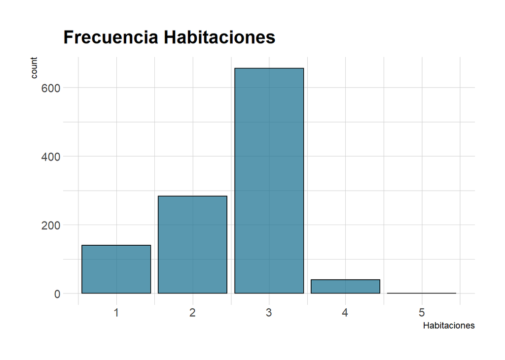

```r
ggplot(base, aes(x = Habitaciones))+
      geom_bar(color="black", fill="#116b8c", alpha = 0.7 ) +
      theme_ipsum() +
      ggtitle('Frecuencia Habitaciones')
```

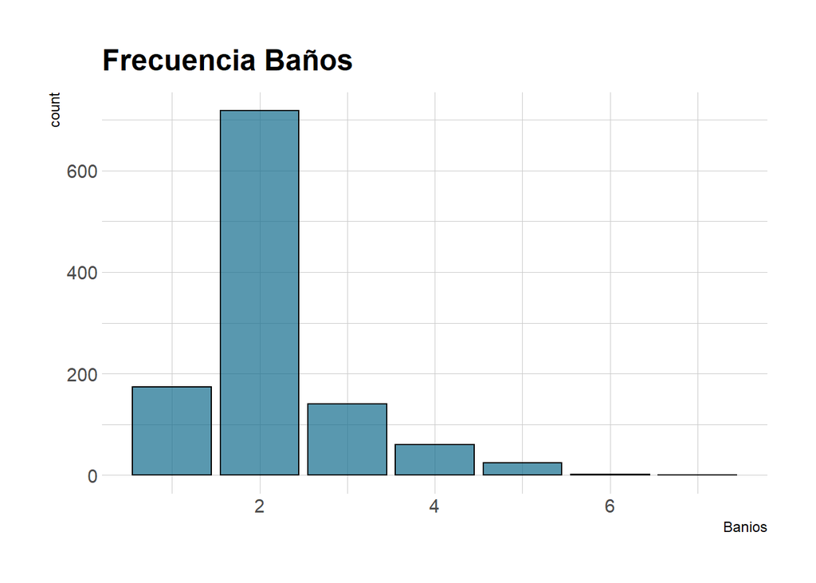

```r
 ggplot(base, aes(x = Banios))+
      geom_bar(color="black", fill="#116b8c", alpha = 0.7 ) +
      theme_ipsum() +
      ggtitle('Frecuencia Baños')
```

## Predicción

### Preparacion de los datos

Para estimar un modelo de predicción de precio de acuerdo con los datos que ya tenemos necesitamos representar la importancia de la ciudad donde se encuentra la vivienda, ya que no es lo mismo un apartamento de 80m2 en Bogotá que en Puerto Colombia.

Para lidiar con los datos categóricos se podría aplicar un one hot encoding a *Ciudad* pero terminarios con un modelo con demasiadas dimensiones para una muestra demasiado pequeña.

En este caso es mejor reemplazar cada ciudad por las veces que aparece en el dataframe de esta manera controlamos por la demanda que existe en cada ciudad ya que esto influye directamente en su precio.

También transformamos la columna de *Precio* para que quede expresada en millones COP.

```r
prediccion = left_join(base, conteo)

col_elim = c('Ciudad', 'Destacado', 'Link')

prediccion = prediccion[, !(names(prediccion) %in% col_elim)]

prediccion['Precio'] = lapply(prediccion['Precio'], function(x)x= x/1000000)

prediccion$Estrato = as.numeric(prediccion$Estrato)
prediccion$Area_m2 = as.numeric(prediccion$Area_m2)

glimpse(prediccion)
```

```
## Rows: 1,120
## Columns: 8
## $ Precio       <dbl> 256.5630, 397.0000, 269.4126, 350.0000, 187.0749, 363.970~
## $ Area_m2      <dbl> 46.65, 69.00, 65.15, 52.64, 46.36, 107.52, 101.90, 24.61,~
## $ Habitaciones <dbl> 3, 3, 2, 1, 1, 3, 2, 3, 3, 1, 2, 3, 1, 3, 2, 3, 3, 1, 3, ~
## $ Banios       <dbl> 2, 2, 2, 2, 2, 4, 3, 2, 2, 1, 1, 2, 1, 3, 1, 2, 2, 1, 3, ~
## $ Parqueadero  <dbl> 2, 2, 2, 2, 2, 4, 3, 2, 2, 1, 1, 2, 1, 3, 1, 2, 2, 1, 3, ~
## $ Estrato      <dbl> 3, 2, 3, 4, 3, 4, 4, 2, 2, 3, 2, 2, 3, 3, 2, 4, 3, 3, 4, ~
## $ Es_destacado <dbl> 1, 0, 0, 0, 0, 0, 0, 1, 0, 0, 0, 0, 0, 0, 0, 1, 0, 0, 0, ~
## $ Freq         <int> 44, 12, 25, 80, 25, 17, 80, 399, 12, 399, 399, 12, 25, 80~
```

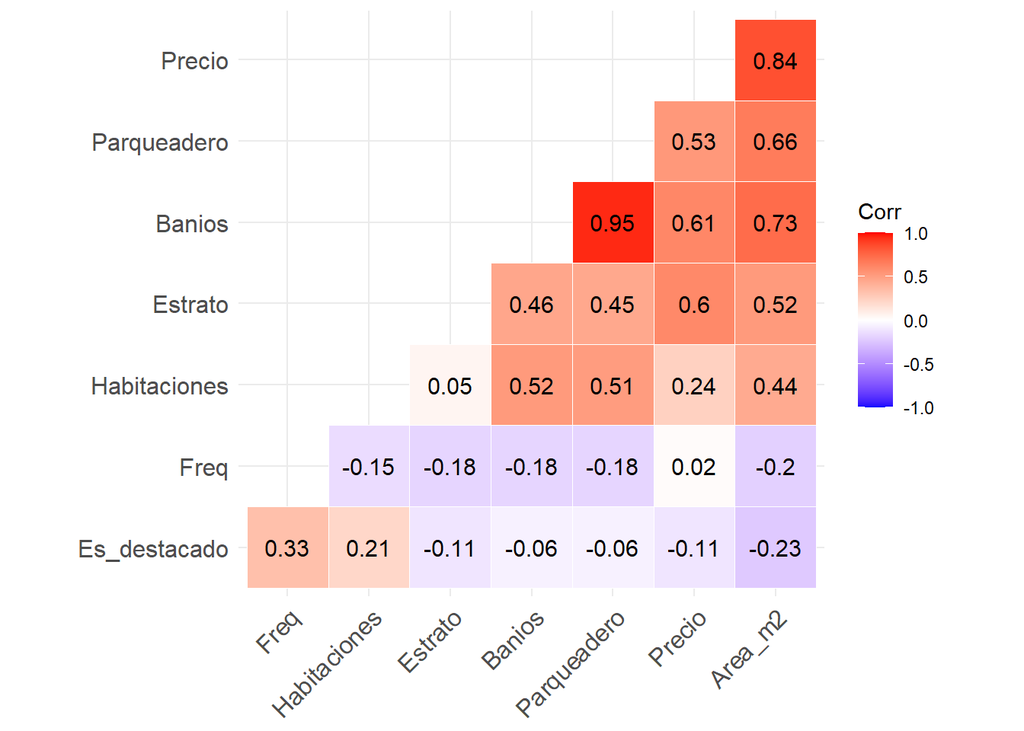

```r
corr <- cor(prediccion)
ggcorrplot(corr, hc.order = TRUE, type = "lower",
     outline.col = "white", lab=T)
```

La gran mayoria de los precios se encuentran por debajo de los 1000 millones COP con promedio de 470 millones y una media de casi 400 millones. Sin embargo, existen outliers entro los 1000 y 4000 millones.

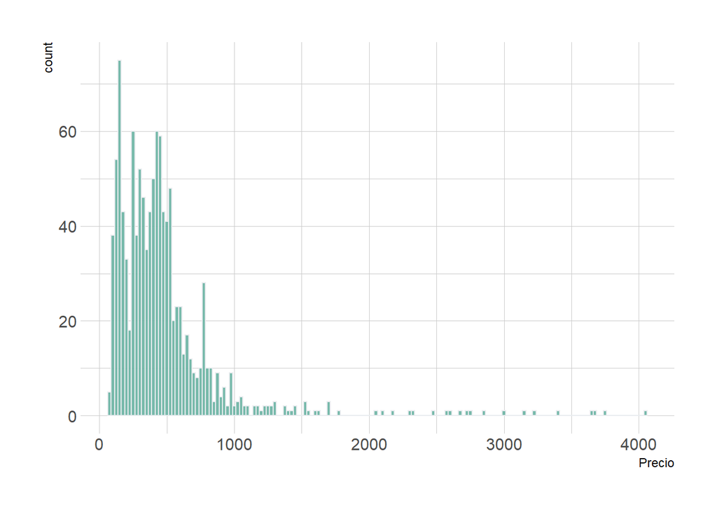

```r
ggplot(prediccion, aes(x = Precio)) + geom_histogram(binwidth=25, fill="#69b3a2", color="#e9ecef", alpha=0.9) + theme_ipsum()
```

```r
summary(prediccion$Precio)
```

```
##    Min. 1st Qu.  Median    Mean 3rd Qu.    Max.
##    77.9   249.2   397.0   472.4   534.9  4055.2
```

Dividimos la base entre entrenamiento y prueba. Dado que vamos a entrenar un Random Forest no es necesario normalizar los datos ya que este modelo no depende de distancia euclidiana.

```r
set.seed(1)

muestra <- sample.split(prediccion$Precio, SplitRatio = .8)

entrenamineto <-  subset(prediccion, muestra == T)
test <- subset(prediccion, muestra == F)
```

### Random Forest

Entrenamos el modelo y graficamos la importancia de cada variable para el modelo.

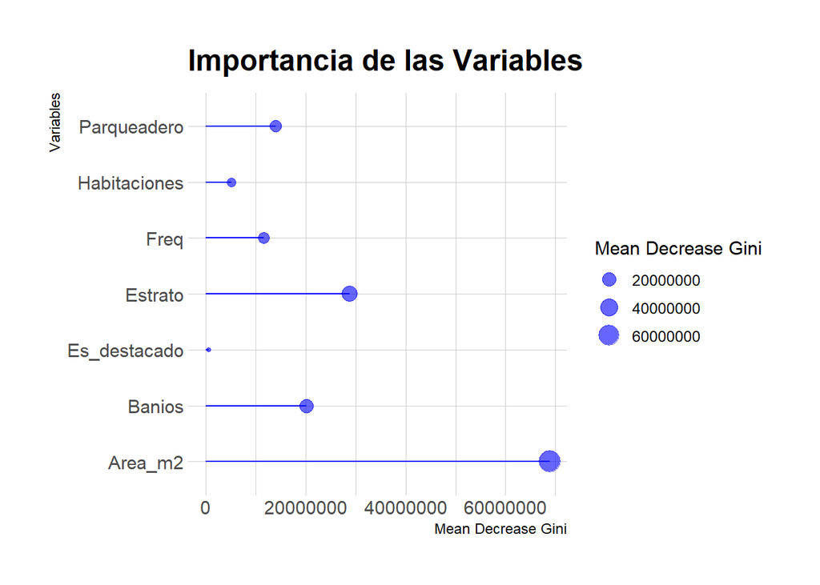

```r
rf <-  randomForest(Precio ~., data = entrenamineto, ntree = 300)

ImpData <- as.data.frame(importance(rf))

ImpData$Variables <- row.names(ImpData)
colnames(ImpData) <- c("Mean Decrease Gini", "Variables")


ggplot(ImpData, aes(x=Variables, y=`Mean Decrease Gini`)) +
                geom_segment( aes(x=Variables, xend=Variables, y=0, yend=`Mean Decrease Gini`), color="blue") +
                geom_point(aes(size = `Mean Decrease Gini`), color="blue", alpha=0.6) +
                theme_light() +
                coord_flip() +
                theme_ipsum() +
                ggtitle('Importancia de las Variables')
```

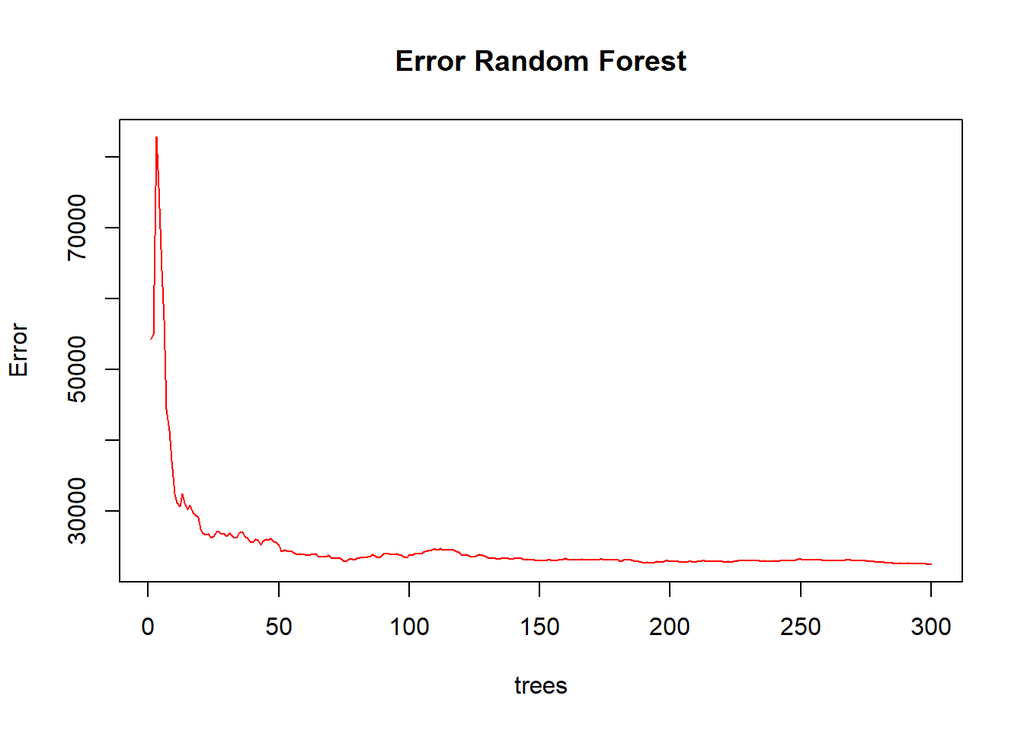

```r
plot(rf, main = "Error Random Forest", col = 'Red')
```

```r
pred <-  predict(rf, newdata = test[-1])

pred_df <-  as.data.frame(pred, col.names ="Pred")

comparacion <- cbind(test[1],pred)

rmse = (sqrt(mean(comparacion$Precio - comparacion$pred)^2))

print(paste('RMSE:', rmse))
```

```
## [1] "RMSE: 9.04419770203682"
```

### SVM

Para entrenar un Support Vector Machine primero debemos estandarizar los datos ya que este modelo si se basa en distancias para generar predicciones:

```r
entrenamiento_est <- as.data.frame(lapply(entrenamineto[-1], function(x) (x-min(x))/(max(x)-min(x))))
entrenamiento_est <- cbind(entrenamiento_est, entrenamineto[1])
test_est <-as.data.frame(lapply(test[-1], function(x) (x-min(x))/(max(x)-min(x))))
test_est <-  cbind(test_est, test[1])
```

Procedemos a generar el modelo y calculamos su RMSE:

```r
modelosvm <-  svm(Precio~.,entrenamiento_est)

pred_svm <- predict(modelosvm, newdata = test_est[1:7])

pred_2 <-  as.data.frame(pred_svm, col.names ="Pred")

comparacion_svm <- cbind(test[1],pred_2)

rmse_svm = (sqrt(mean(comparacion_svm$Precio - comparacion_svm$pred)^2))

print(paste('RMSE:', rmse_svm))
```

```
## [1] "RMSE: 123.884686911362"
```

Podemos observar una gran diferencia entre el RSME del random forest y del SVM, sin embargo la explicación mas factible es que el RMSE tan pequeño del random forest se debe a overfitting. Mejorar el modelo se puede trabajar mas adelante pero por ahora ese es el modelo que se usara para generar predicciones en el tablero de control.

```r
saveRDS(rf, 'rf.rds')
```

[Tablero](https://krrrr.shinyapps.io/tablero/?_ga=2.176201317.1311163216.1649061031-1629539394.1647569523)